# BOO 2025

Script 4: PCA

Adam Seuren

2025-05-21

> In this script, you will perform principal component analysis (PCA) to further explore patterns in the project data.

# 1 Setup

## 1.1 Clean

As before, we perform several setup steps at the start of the script to ensure our work is reproducible and clear.

**Exercise 1: Download the R markdown template, clean your environment, and set the following variables:**

- `root_dir` - project folder
- `cpm_path` - location of the `cpmData` object
- `metadata_path` - location of the `metaData` object

```r
#
rm(list=ls())
root_dir <- "C:/Users/mmpse/Documents/GitHub/BOO-Adam/QC/04_PCA/"
cpm_path <- "Input/cpmData.Rdata"
metadata_path <- "Input/metaData.Rdata"
count_path <- "Input/countData.Rdata"
```

## 1.2 Packages

Two new packages are introduced in this script:

- `ComplexHeatmap` allows the drawing and annotation of heatmaps in R
- `circlize` allows for the drawing of circular plots, but is also used by `ComplexHeatmap` for colour functions like `colorRamp2()`

**Exercise 2: Load these packages alongside `tidyverse` into your R environment:**

```r
#
library(tidyverse)
library(circlize)
library(ComplexHeatmap)
library(ggrepel)
```

## 1.3 Load data

**Exercise 3: Load the CPM and metadata into your R environment:**

```r
#
load(paste0(root_dir, cpm_path))
load(paste0(root_dir, metadata_path))
load(paste0(root_dir, count_path))
```

# 2 PCA

## 2.1 Calculate

In high dimensional data (such as this data with around 10,000 genes), principal components (PCs) can be calculated and used to explore patterns. PCs can be thought of as a new axis in the data that captures the most variance possible in the fewest variables.

**Exercise 4: Use the `prcomp()` function to calculate PCs of the `cpmData`:**

```r
# The prcomp function is used for calculating the principal components of the cpmdata.
pcs <- prcomp(t(cpmData))
```

Tolerance (or `tol`) can be adjusted to create more or fewer PCs, where a lower tolerance generates a higher number. If this argument is not set, the PCs calculated will capture the full variability of the CPM data.

## 2.2 Variance explained

**Exercise 5: Use the output of `prcomp()` to explore your PCs and calculate the variance in CPM values that they explain:**

**Hint**

Variance explained is the SD squared divided by the sum of the variance for all PCs.

```r
#
summary(pcs)
```

```
## Importance of components:
##                              PC1       PC2       PC3       PC4       PC5
## Standard deviation     3239.9107 1996.5999 1.094e+03 832.66162 692.21193
## Proportion of Variance    0.5517    0.2095 6.286e-02   0.03644   0.02518
## Cumulative Proportion     0.5517    0.7612 8.241e-01   0.86055   0.88573
##                             PC6       PC7       PC8       PC9      PC10
## Standard deviation     499.1461 460.02158 443.10878 404.63377 395.51373
## Proportion of Variance   0.0131   0.01112   0.01032   0.00861   0.00822
## Cumulative Proportion    0.8988   0.90995   0.92027   0.92887   0.93710
##                             PC11      PC12      PC13      PC14      PC15
## Standard deviation     289.68866 271.64208 244.05705 234.66747 227.30389
## Proportion of Variance   0.00441   0.00388   0.00313   0.00289   0.00272
## Cumulative Proportion    0.94151   0.94538   0.94852   0.95141   0.95413
##                             PC16      PC17      PC18      PC19      PC20
## Standard deviation     218.75361 203.32226 200.36849 186.23251 178.68718
## Proportion of Variance   0.00252   0.00217   0.00211   0.00182   0.00168
## Cumulative Proportion    0.95664   0.95881   0.96092   0.96275   0.96442
##                             PC21      PC22      PC23      PC24      PC25
## Standard deviation     174.75652 171.65615 163.86762 161.22242 155.18372
## Proportion of Variance   0.00161   0.00155   0.00141   0.00137   0.00127
## Cumulative Proportion    0.96603   0.96758   0.96899   0.97036   0.97162
##                            PC26      PC27      PC28      PC29      PC30
## Standard deviation     151.0969 148.24509 143.27771 140.44082 136.91459
## Proportion of Variance   0.0012   0.00116   0.00108   0.00104   0.00099
## Cumulative Proportion    0.9728   0.97398   0.97506   0.97609   0.97708
##                             PC31     PC32      PC33      PC34      PC35
## Standard deviation     133.39696 130.8831 129.93090 128.00130 125.86431
## Proportion of Variance   0.00094   0.0009   0.00089   0.00086   0.00083
## Cumulative Proportion    0.97801   0.9789   0.97980   0.98066   0.98149
##                             PC36      PC37      PC38      PC39      PC40
## Standard deviation     125.13985 124.20990 122.65118 120.66332 119.14994
## Proportion of Variance   0.00082   0.00081   0.00079   0.00077   0.00075
## Cumulative Proportion    0.98232   0.98313   0.98392   0.98468   0.98543
##                             PC41      PC42      PC43      PC44      PC45
## Standard deviation     118.31580 117.30499 114.87770 114.13588 112.65109
## Proportion of Variance   0.00074   0.00072   0.00069   0.00068   0.00067
## Cumulative Proportion    0.98617   0.98689   0.98758   0.98827   0.98893
##                             PC46      PC47      PC48      PC49      PC50
## Standard deviation     112.15887 111.44979 110.94468 108.51583 108.14431
## Proportion of Variance   0.00066   0.00065   0.00065   0.00062   0.00061
## Cumulative Proportion    0.98960   0.99025   0.99090   0.99151   0.99213
##                            PC51      PC52      PC53      PC54      PC55
## Standard deviation     107.1304 105.51658 104.85667 103.51185 102.50831
## Proportion of Variance   0.0006   0.00059   0.00058   0.00056   0.00055
## Cumulative Proportion    0.9927   0.99332   0.99390   0.99446   0.99501
##                             PC56      PC57     PC58     PC59    PC60     PC61
## Standard deviation     101.63625 101.27152 99.44764 98.24954 97.7243 96.96904
## Proportion of Variance   0.00054   0.00054  0.00052  0.00051  0.0005  0.00049
## Cumulative Proportion    0.99555   0.99609  0.99661  0.99712  0.9976  0.99812
##                            PC62     PC63     PC64     PC65      PC66
## Standard deviation     96.02603 95.78475 94.92880 91.83029 2.774e-12
## Proportion of Variance  0.00048  0.00048  0.00047  0.00044 0.000e+00
## Cumulative Proportion   0.99860  0.99908  0.99956  1.00000 1.000e+00
```

```r
# The variance explained by each principal component is calculated with the aforementioned formula: the standard deviance squared (= variance), divided by the sum of the variance (= SD squared) for all PCs. It is rounded to 3 decimals.
var_explained =
  data.frame(
    # The first column indicates the PC, the second column indicates the variance explained by that PC
    PC = 1:nrow(metaData),
             var_explained = round(pcs$sdev^2 / sum(pcs$sdev^2), 3))

var_explained
```

| PC | var_explained |
| --- | --- |
| 1 | 0.552 |
| 2 | 0.210 |
| 3 | 0.063 |
| 4 | 0.036 |
| 5 | 0.025 |
| 6 | 0.013 |
| 7 | 0.011 |
| 8 | 0.010 |
| 9 | 0.009 |
| 10 | 0.008 |

[output cut: 56 more lines]

## 2.3 Screeplot

A screeplot can be used to visualize how each subsequent PC captures less and less of the total variance in the data.

**Exercise 6: Plot the top 20 calculated PCs against the variance they explain to generate a screeplot:**

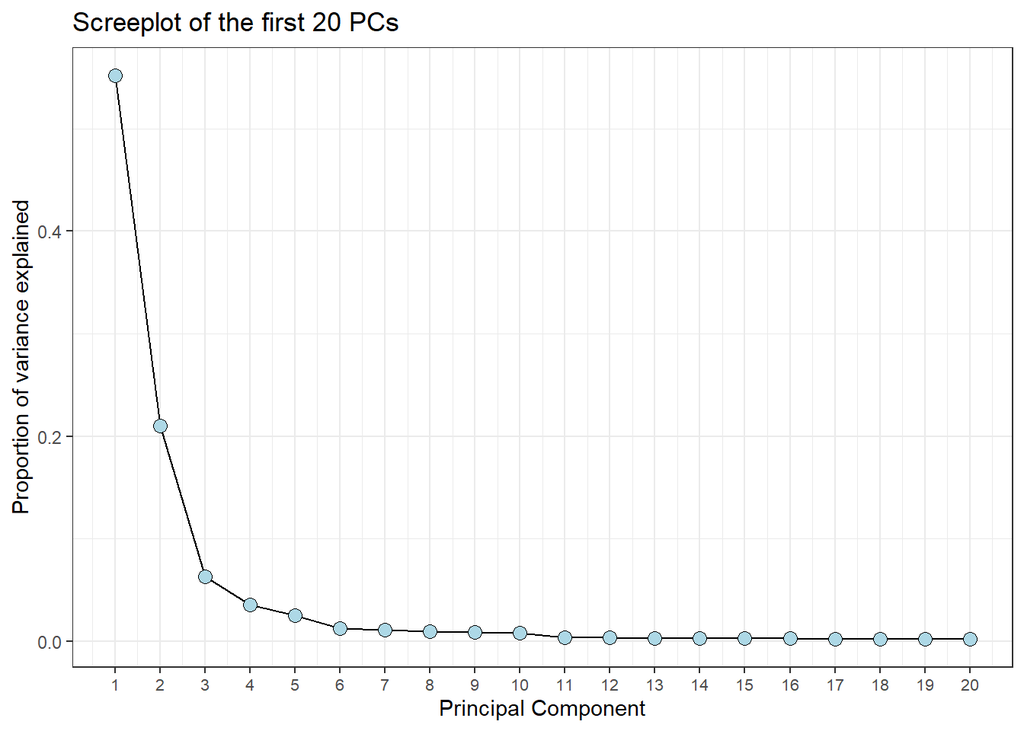

```r
#
var_explained %>%
  # The first 20 PCs are selected to be plotted (PC number is equal to or less than 20)
  filter(PC <= 20) %>%
  # The proportion of the variance explained by each principal component is plotted in a line plot, with a point for each PC.
  ggplot(aes(x = PC, y = var_explained)) +
  geom_line(color = "black") +
  geom_point(color = "black", fill = 'lightblue', shape = 21, size = 3) +
  # The x-axis is labelled from 1 to 20
  scale_x_continuous(breaks = c(seq(1,20))) +
  xlab("Principal Component") +
  ylab("Proportion of variance explained") +
  ggtitle("Screeplot of the first 20 PCs") +
  theme_bw() +
  theme(axis.text.x = element_text(size = 8))
```